# virginia-migrant-children-analysis

Amelie Fawson

2025-11-03

# Visuals for Draft Pitch

This document holds two charts that support my **draft story pitch**: - **Chart A:** Group comparison (e.g., top ZIPs/counties or sponsor_type categories) - **Chart B:** Change over time (monthly)

## Chart A — Group comparison (bar)

**Goal:** Compare values across groups (e.g., top 10 ZIP codes or counties).

**NOTE:** I included a companion chart to show both per-capita rates and total placements. The rate chart shows the rural counties where small numbers have big proportional impacts and the count chart shows where the largest numbers of children actually settled. I think that having both charts helps avoid small-sample distortion and gives readers / the audience a fuller picture of Virginia’s unaccompanied children placement patterns.

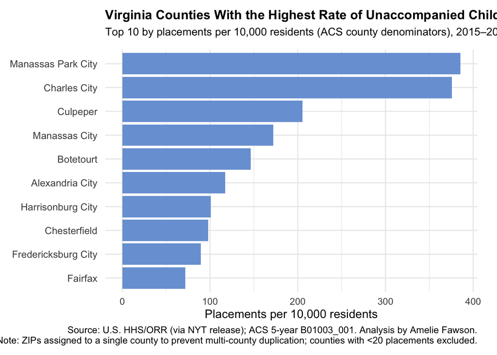

```r
pA <- ggplot(
  va_top10_rate_acs,
  aes(x = reorder(county_clean, rate_per_10k), y = rate_per_10k)
) +
  geom_col(fill = brand_blue) +
  coord_flip() +
  labs(
    title    = "Virginia Counties With the Highest Rate of Unaccompanied Child Placements",
    subtitle = "Top 10 by placements per 10,000 residents (ACS county denominators), 2015–2023",
    x = NULL,
    y = "Placements per 10,000 residents",
    caption = "Source: U.S. HHS/ORR (via NYT release); ACS 5-year B01003_001. Analysis by Amelie Fawson.\nNote: ZIPs assigned to a single county to prevent multi-county duplication; counties with <20 placements excluded."
  ) +
  scale_x_discrete(labels = stringr::str_to_title) +
  scale_y_continuous(labels = comma_format()) +
  theme_minimal(base_size = 12) +
  theme(
    plot.title    = element_text(size = 13, face = "bold", margin = margin(b = 6)),
    plot.subtitle = element_text(size = 11, margin = margin(b = 12)),
    axis.text.y   = element_text(size = 10, margin = margin(r = 5)),
    plot.margin   = margin(10, 20, 10, 10)
  )

pA
```

```r
ggsave("vizA_Fawson.png", pA, width = 8.5, height = 5.2, dpi = 350, bg = "white")
```

**Takeaway (1-2 sentences):** Small jurisdictions (often independent cities) post the highest per-capita placement rates, indicating concentrated impact despite lower overall counts.

## Chart A2 — Companion Chart: Total Placements by County

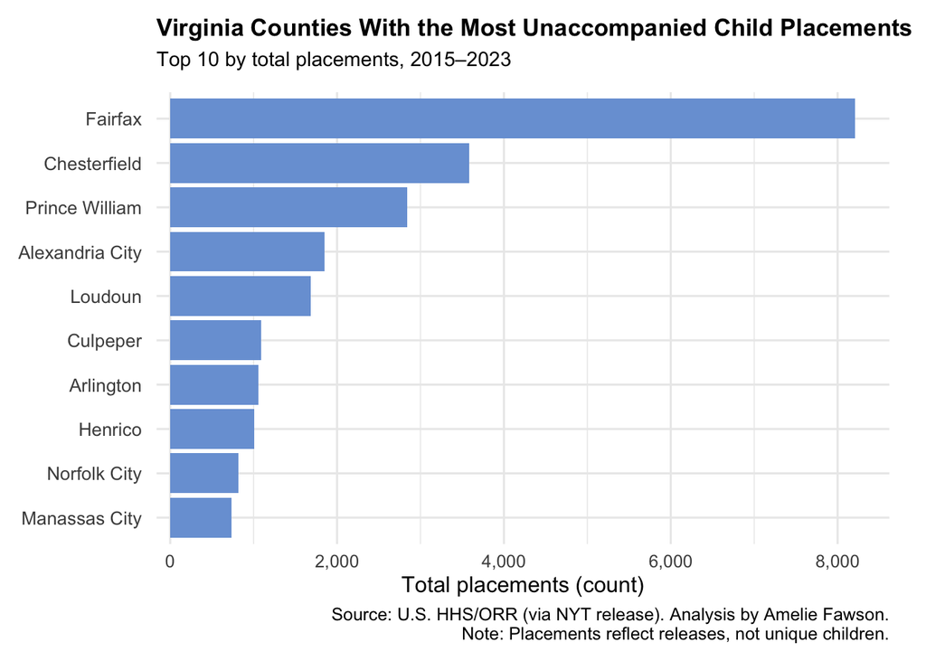

```r
pA2 <- ggplot(
  va_top10_counts_acs,
  aes(x = reorder(county_clean, placements), y = placements)
) +
  geom_col(fill = brand_blue) +
  coord_flip() +
  labs(
    title    = "Virginia Counties With the Most Unaccompanied Child Placements",
    subtitle = "Top 10 by total placements, 2015–2023",
    x = NULL,
    y = "Total placements (count)",
    caption = "Source: U.S. HHS/ORR (via NYT release). Analysis by Amelie Fawson.\nNote: Placements reflect releases, not unique children."
  ) +
  scale_x_discrete(labels = stringr::str_to_title) +
  scale_y_continuous(labels = comma_format(), breaks = pretty_breaks(6), expand = expansion(mult = c(0.02, 0.05))) +
  theme_minimal(base_size = 12) +
  theme(
    plot.title    = element_text(size = 13, face = "bold", margin = margin(b = 6)),
    plot.subtitle = element_text(size = 11, margin = margin(b = 12)),
    axis.text.y   = element_text(size = 10, margin = margin(r = 5)),
    plot.margin   = margin(10, 20, 10, 10)
  )

pA2
```

```r
ggsave("vizA2_Fawson.png", pA2, width = 8.5, height = 5.2, dpi = 350, bg = "white")
```

## Chart B — Change over time, monthly (line)

**Goal:** Show monthly change (counts).

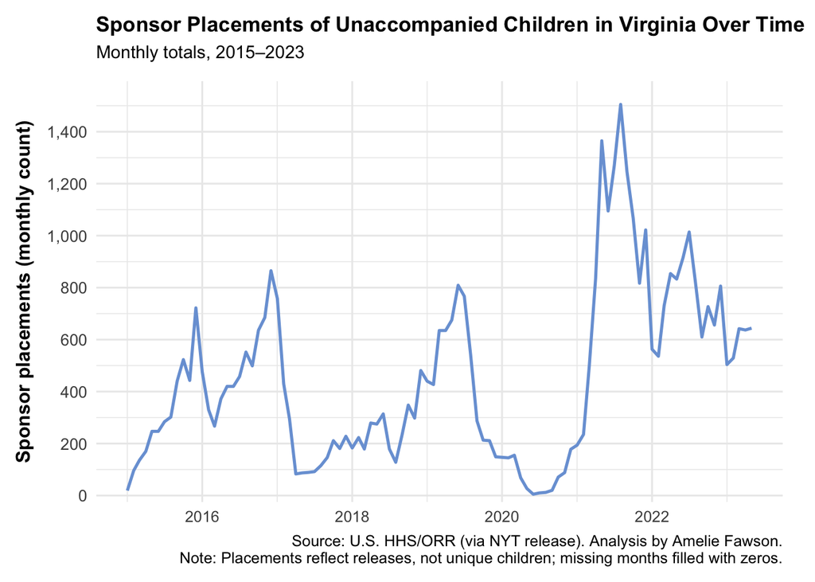

```r
mc_va_monthly <- nyt_mc_va %>%
  filter(!is.na(date)) %>%
  mutate(month = floor_date(date, "month")) %>%
  count(month, name = "placements") %>%
  complete(month = seq.Date(min(month), max(month), by = "month"),
           fill = list(placements = 0))

pB <- ggplot(mc_va_monthly, aes(x = month, y = placements)) +
  geom_line(linewidth = 0.9, color = brand_blue) +
  labs(
    title    = "Sponsor Placements of Unaccompanied Children in Virginia Over Time",
    subtitle = "Monthly totals, 2015–2023",
    x = NULL,
    y = "Sponsor placements (monthly count)",
    caption = "Source: U.S. HHS/ORR (via NYT release). Analysis by Amelie Fawson.\nNote: Placements reflect releases, not unique children; missing months filled with zeros."
  ) +
  scale_y_continuous(labels = comma_format(), breaks = pretty_breaks(6), expand = expansion(mult = c(0.02, 0.06))) +
  theme_minimal(base_size = 12) +
  theme(
    plot.title    = element_text(size = 13, face = "bold", margin = margin(b = 6)),
    plot.subtitle = element_text(size = 11, margin = margin(b = 12)),
    axis.title.y  = element_text(size = 12, face = "bold", margin = margin(r = 8)),
    axis.text.y   = element_text(size = 10),
    plot.margin   = margin(10, 20, 10, 10)
  )

pB
```

```r
ggsave("vizB_Fawson.png", pB, width = 10, height = 6, dpi = 300, bg = "white")
```

**Takeaway (1–2 sentences):** Monthly placements spike in specific periods and remain elevated across multiple years, signaling sustained pressure on schools and services.